# Работа на стриме (Д.З ниже)

```python
import pandas
#importing pandas
```

```python
rates=pandas.read_excel("usd_rates.xlsx")
#importing data from exel
```

```python
rates.head()
```

|  | nominal | data | curs | cdx |
| --- | --- | --- | --- | --- |
| 0 | 1 | 2017-01-10 | 59.8961 | Доллар США |
| 1 | 1 | 2017-01-11 | 59.9533 | Доллар США |
| 2 | 1 | 2017-01-12 | 60.1614 | Доллар США |
| 3 | 1 | 2017-01-13 | 59.4978 | Доллар США |
| 4 | 1 | 2017-01-14 | 59.3700 | Доллар США |

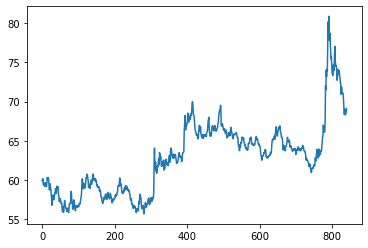

```python
rates.curs.plot()
```

```python
#Прогноз курса на 7 дней
```

```python
# за 28 дней назад => прогноз на 7 дней
```

```python
past = 28
future = 7
start = past # начинаем с 28 дня
end = len(rates.curs)-future # заканчиваем рассмотрение на 7 дне с конца
end - start
```

```
806
```

```python
dataframe=[]
for day in range(start,end):
    # Взять 28 дней в прошлом и 7 дней в будущем и сложить в таблицу в
    # удобном для модели виде
    past_data = list(rates.curs[(day-past):day])
    future_data = list(rates.curs[day:day+future])
    dataframe.append(past_data+future_data)
```

```python
past_columns = []
for i in range(past):
    past_columns.append(f'past_{i}')
past_columns
```

```
['past_0',
 'past_1',
 'past_2',
 'past_3',
 'past_4',
 'past_5',
 'past_6',
 'past_7',
 'past_8',
 'past_9',
 'past_10',
 'past_11',
 'past_12',
 'past_13',
 'past_14',
 'past_15',
 'past_16',
 'past_17',
 'past_18',
 'past_19',
 'past_20',
 'past_21',
 'past_22',
 'past_23',
 'past_24',
 'past_25',
 'past_26',
 'past_27']
```

```python
future_columns = []
for i in range(future):
    future_columns.append(f'future_{i}')
future_columns
```

```
['future_0',
 'future_1',
 'future_2',
 'future_3',
 'future_4',
 'future_5',
 'future_6']
```

```python
usd=pandas.DataFrame(dataframe,columns=past_columns+future_columns)
```

```python
X = usd[past_columns] # Входные данные
```

```python
Y = usd[future_columns] # Выходные данные
```

```python
#Тренировочная выборка, эта та, на которой мы тренируем модель, УЧЕБНИК
X_train = X[:-10]#УЧЕБНИК
Y_train = Y[:-10]#ОТВЕТЫ
```

```python
#Тестовоя выборка, это та на которой мы проверим качество обучения модели
X_test=X[-10:]#Задачи экзамена
Y_test=Y[-10:]#Ответы на экзамен
```

```python
from sklearn.linear_model import LinearRegression
```

```python
linreg = LinearRegression()#Объект модели
```

```python
linreg.fit(X_train,Y_train)
```

```
LinearRegression()
```

```python
X_test.head(1)# Первый вопрос на экзамене
```

|  | past_0 | past_1 | past_2 | past_3 | past_4 | past_5 | past_6 | past_7 | past_8 | past_9 | ... | past_18 | past_19 | past_20 | past_21 | past_22 | past_23 | past_24 | past_25 | past_26 | past_27 |
| --- | --- | --- | --- | --- | --- | --- | --- | --- | --- | --- | --- | --- | --- | --- | --- | --- | --- | --- | --- | --- | --- |
| 796 | 76.4074 | 75.455 | 75.7499 | 74.605 | 73.7515 | 73.5245 | 73.315 | 73.7145 | 74.7119 | 73.9441 | ... | 72.7263 | 73.9719 | 74.1169 | 73.8725 | 73.4326 | 73.5819 | 73.9298 | 73.2056 | 72.9798 | 72.3918 |

1 rows × 28 columns

```python
firstDayReal = Y_test.head(1)
firstDay = X_test.head(1)
prediction=linreg.predict(firstDay)
```

```python
from sklearn.metrics import mean_absolute_error
```

```python
mean_absolute_error(prediction[0],firstDayReal.iloc[0])
```

```
0.7382858976275101
```

```python
import matplotlib.pyplot as plt
```

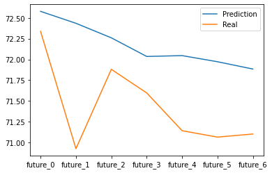

```python
plt.plot(prediction[0],label='Prediction')
plt.plot(firstDayReal.iloc[0],label='Real')
plt.legend()
```

```
mae=0.5573096584181586
```

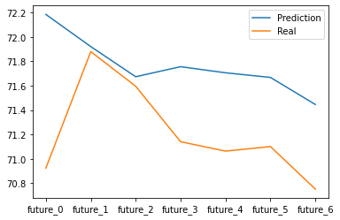

```python
prediction=linreg.predict([X_test.iloc[1]])
real=Y_test.iloc[1]
mae = mean_absolute_error(prediction[0], real)
print(f'mae={mae}')
plt.plot(prediction[0],label='Prediction')
plt.plot(real,label='Real')
plt.legend()
```

```python
from sklearn.neighbors import KNeighborsRegressor
```

```python
knn = KNeighborsRegressor(n_neighbors=2)# парраметр - количество соседей
knn.fit(X_train,Y_train)
```

```
KNeighborsRegressor(n_neighbors=2)
```

```
mae=0.4479214285714233
```

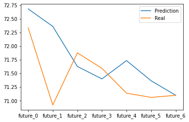

```python
prediction=knn.predict([X_test.iloc[0]])
real=Y_test.iloc[0]
mae = mean_absolute_error(prediction[0], real)
print(f'mae={mae}')
plt.plot(prediction[0],label='Prediction')
plt.plot(real,label='Real')
plt.legend()
```

# Домашняя работа

# Работа с нейросетью

```python
#НЕЙРОНКИ
```

```python
from sklearn.neural_network import MLPRegressor
```

ПЕРВАЯ МОДЕЛЬ

```python
mlp_1 = MLPRegressor(max_iter=1000,hidden_layer_sizes=(100,100,200,100,200), random_state=42)
```

```python
from datetime import datetime
import time
start_time = datetime.now()
mlp_1.fit(X_train,Y_train)
print(f'Время обучения: {datetime.now() - start_time}')
```

```
Время обучения: 0:00:09.978570
```

```
mae=0.5397594176653838
```

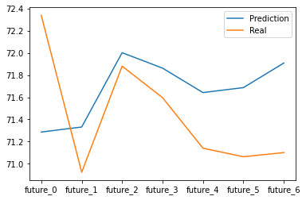

```python
prediction=mlp_1.predict([X_test.iloc[0]])
real=Y_test.iloc[0]
mae = mean_absolute_error(prediction[0], real)
print(f'mae={mae}')
plt.plot(prediction[0],label='Prediction')
plt.plot(real,label='Real')
plt.legend()
```

ВТОРАЯ МОДЕЛЬ

```python
mlp = MLPRegressor(max_iter=5000,hidden_layer_sizes=(1500,1500,1500), random_state=42)
```

```python
from datetime import datetime
import time
start_time = datetime.now()
mlp.fit(X_train,Y_train)
print(f'Время обучения: {datetime.now() - start_time}')
```

```
Время обучения: 0:05:22.252590
```

```
mae=0.7340729546649912
```

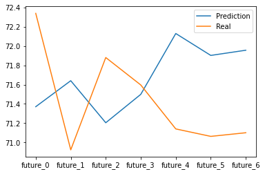

```python
prediction=mlp.predict([X_test.iloc[0]])
real=Y_test.iloc[0]
mae = mean_absolute_error(prediction[0], real)
print(f'mae={mae}')
plt.plot(prediction[0],label='Prediction')
plt.plot(real,label='Real')
plt.legend()
```

Были выработаны две модели:

- Model_100_100_200_100_200_iter_1000.pkl

Значения 10 тестовых выборок:

- mae=0.5397594176653838
- mae=0.7200269183535843
- mae=0.7278825969365305
- mae=0.9558553779591027
- mae=1.1187469000873855
- mae=1.1610832865723049
- mae=1.3252241366541813
- mae=1.388345049921804
- mae=1.0428634573394138
- mae=0.4952964610267401

Минимальная ошибка:0.4952964610267401

Дисперсия: 0.0990937147696078

Размах: 0,89304

- Model_1500_1500_1500_iter_5000.pkl

Значения 10 тестовых выборок:

- mae=0.7340729546649912
- mae=0.5932245848576798
- mae=0.7172120096019553
- mae=0.9259348501620062
- mae=1.1734832207188464
- mae=1.2800229037003885
- mae=1.2343095908712687
- mae=1.3156086080112377
- mae=1.2383230927766289
- mae=1.0070904126107527

Минимальная ошибка: 0.5932245848576798

Дисперсия: 0.07074409544250496

Размах: 0.7223840231535579

В результате исследований была выбрана вторая модель. У второй модели есть ряд преимуществ:

- Меньшая дисперсия средних абсолютных ошибок на тестовой выборке
- Меньший размах средних абсолютных ошибок на тестовой выборке Недостатки второй модели:
- Время обучения: 0:05:22.252590

Обе модели сохранены в файлах и выложены на гитхабе и google drive(.pkl файл второй модели 142 МБайта):

- Модель1:https://github.com/goglevivan2/ForDSLessons/blob/master/Model_100_100_200_100_200_iter_1000.pkl
- Модель2:https://drive.google.com/file/d/1N0Jfj0NUg_p4U8s-9OjULbZPtSvMinCw/view?usp=sharing

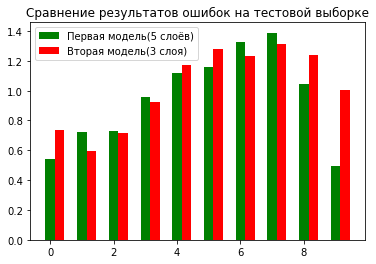

```python
array_of_mae_1=[
    0.5397594176653838,
    0.7200269183535843,
    0.7278825969365305,
    0.9558553779591027,
    1.1187469000873855,
    1.1610832865723049,
    1.3252241366541813,
    1.388345049921804,
    1.0428634573394138,
    0.4952964610267401,
]

array_of_mae_2=[
0.7340729546649912,
0.5932245848576798,
0.7172120096019553,
0.9259348501620062,
1.1734832207188464,
1.2800229037003885,
1.2343095908712687,
1.3156086080112377,
1.2383230927766289,
1.0070904126107527,
]
import numpy as np
plt.bar(np.arange(10)+0.0,array_of_mae_1,color='green',label='Первая модель(5 слоёв)',width = 0.3)
plt.bar(np.arange(10)+0.3,array_of_mae_2,color='red',label='Вторая модель(3 слоя)',width = 0.3)
plt.title('Сравнение результатов ошибок на тестовой выборке')
plt.legend()
```

ЗАПИСЬ МОДЕЛИ В ФАЙЛ

```python
import joblib
joblib.dump(mlp,'Model_1500_1500_1500_iter_5000.pkl')
```

```
['Model_1500_1500_1500_iter_5000.pkl']
```

```python
import pickle
# save the model to disk
filename = 'Model_100_100_200_100_200_iter_1000.sav'
pickle.dump(mlp, open(filename, 'wb'))
```

[output not shown]

[figure not shown]

```python
l= pickle.load(open(filename, 'rb'))
prediction=l.predict([X_test.iloc[0]])
real=Y_test.iloc[0]
mae = mean_absolute_error(prediction[0], real)
print(f'mae={mae}')
plt.plot(prediction[0],label='Prediction')
plt.plot(real,label='Real')
plt.legend()
```

ФУНКЦИИ ДЛЯ СТАТИСТИЧЕСКОГО АНАЛИЗА

```python
def mean(x):
    return sum(x)/len(x)
```

```python
#
def de_mean(x):
    x_bar=mean(x)
    return[x_i-x_bar for x_i in x]
```

```python
def dot(v,w):
    return sum(v_i*w_i for v_i,w_i in zip(v,w))

def sum_of_squares(v):
    return dot(v,v)
```

```python
#
def variance(x):
    n=len(x)
    deviations=de_mean(x)
    return sum_of_squares(deviations)/(n-1)
```

```python
er={
0.7340729546649912,
0.5932245848576798,
0.7172120096019553,
0.9259348501620062,
1.1734832207188464,
1.2800229037003885,
1.2343095908712687,
1.3156086080112377,
1.2383230927766289,
1.0070904126107527,
}
```

```python
variance(er)
```

```
0.07074409544250496
```

```python
max(er)-min(er)
```

```
0.7223840231535579
```

# Тестирование других методов регрессинга

# #RandomForestRegressor

```python
from  sklearn.ensemble import RandomForestRegressor
```

```python
rfr = RandomForestRegressor()
```

```python
start_time = datetime.now()
rfr.fit(X_train,Y_train)
print(f'Время обучения: {datetime.now() - start_time}')
```

```
Время обучения: 0:00:03.263659
```

```
mae=1.9040608571428888
```

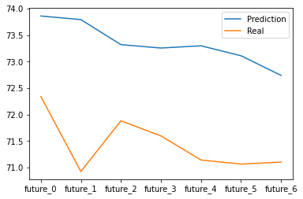

```python
prediction=rfr.predict([X_test.iloc[0]])
real=Y_test.iloc[0]
mae = mean_absolute_error(prediction[0], real)
print(f'mae={mae}')
plt.plot(prediction[0],label='Prediction')
plt.plot(real,label='Real')
plt.legend()
```

```python
array_mae=[]
for i in range(10):
    prediction=rfr.predict([X_test.iloc[i]])
    real=Y_test.iloc[i]
    mae = mean_absolute_error(prediction[0], real)
    array_mae.append(mae)
    print(f'mae[{i}]={mae}')
v=variance(array_mae)
print(f'Дисперсия :{v}')
razm=max(array_mae)- min(array_mae)
print(f'Размах:{razm}')
```

```
mae[0]=1.9040608571428888
mae[1]=2.6146657142857372
mae[2]=0.9432950000000123
mae[3]=3.2284201428571526
mae[4]=3.6527481428571553
mae[5]=3.697308285714308
mae[6]=3.990224571428596
mae[7]=4.322868428571454
mae[8]=2.65400042857143
mae[9]=0.6956039999999929
Дисперсия :1.5752273855240893
Размах:3.627264428571461
```

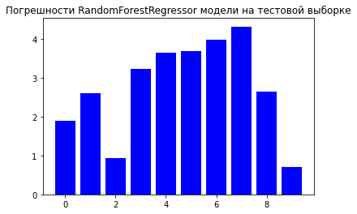

```python
plt.bar(np.arange(10)+0.0,array_mae,color='blue')
plt.title('Погрешности RandomForestRegressor модели на тестовой выборке')
```

# #PLSRegression

```python
from sklearn.cross_decomposition import PLSRegression
```

```python
rlsr = PLSRegression()
```

```python
start_time = datetime.now()
rlsr.fit(X_train,Y_train)
print(f'Время обучения: {datetime.now() - start_time}')
```

```
Время обучения: 0:00:00.243678
```

```
mae=1.2370287165693574
```

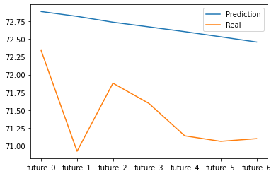

```python
prediction=rlsr.predict([X_test.iloc[0]])
real=Y_test.iloc[0]
mae = mean_absolute_error(prediction[0], real)
print(f'mae={mae}')
plt.plot(prediction[0],label='Prediction')
plt.plot(real,label='Real')
plt.legend()
```

```python
array_mae_plsr=[]
for i in range(10):
    prediction=rlsr.predict([X_test.iloc[i]])
    real=Y_test.iloc[i]
    mae = mean_absolute_error(prediction[0], real)
    array_mae_plsr.append(mae)
    print(f'mae[{i}]={mae}')
v=variance(array_mae_plsr)
print(f'Дисперсия :{v}')
razm=max(array_mae_plsr)- min(array_mae_plsr)
print(f'Размах:{razm}')
```

```
mae[0]=1.2370287165693574
mae[1]=1.3041668637260955
mae[2]=1.0989322965322401
mae[3]=1.3226624342125137
mae[4]=1.543614528197533
mae[5]=1.5345619944594782
mae[6]=1.5814218742072106
mae[7]=1.7109052780407734
mae[8]=1.7325169283824684
mae[9]=1.5270256159913629
Дисперсия :0.04358133793466826
Размах:0.6335846318502283
```

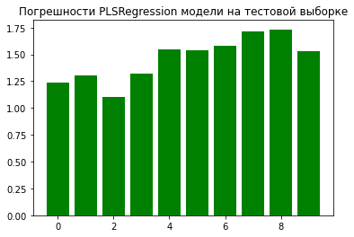

```python
plt.bar(np.arange(10)+0.0,array_mae_plsr,color='green')
plt.title('Погрешности PLSRegression модели на тестовой выборке')
```

# #BaggingRegressor

```python
from sklearn.ensemble import BaggingRegressor
```

```python
br=BaggingRegressor()
```

```python
start_time = datetime.now()
br.fit(X_train,Y_train)
print(f'Время обучения: {datetime.now() - start_time}')
```

```
Время обучения: 0:00:00.595634
```

```
mae=1.3410385714285695
```

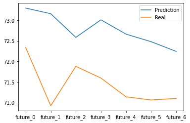

```python
prediction=br.predict([X_test.iloc[0]])
real=Y_test.iloc[0]
mae = mean_absolute_error(prediction[0], real)
print(f'mae={mae}')
plt.plot(prediction[0],label='Prediction')
plt.plot(real,label='Real')
plt.legend()
```

```python
array_mae_br=[]
for i in range(10):
    prediction=br.predict([X_test.iloc[i]])
    real=Y_test.iloc[i]
    mae = mean_absolute_error(prediction[0], real)
    array_mae_br.append(mae)
    print(f'mae[{i}]={mae}')
v=variance(array_mae_br)
print(f'Дисперсия :{v}')
razm=max(array_mae_br)- min(array_mae_br)
print(f'Размах:{razm}')
```

```
mae[0]=1.3410385714285695
mae[1]=2.533041428571429
mae[2]=0.6604899999999999
mae[3]=2.4792400000000003
mae[4]=3.695145714285715
mae[5]=3.9595785714285716
mae[6]=4.246154285714283
mae[7]=4.651415714285717
mae[8]=2.9598757142857193
mae[9]=1.7400942857142883
Дисперсия :1.7430129821749665
Размах:3.990925714285717
```

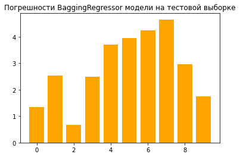

```python
plt.bar(np.arange(10)+0.0,array_mae_br,color='orange')
plt.title('Погрешности BaggingRegressor модели на тестовой выборке')
```

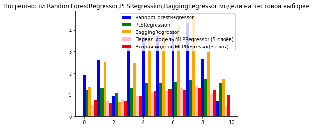

```python
plt.bar(np.arange(10)+0.0,array_mae,color='blue',width=0.2,label='RandomForestRegressor')
plt.bar(np.arange(10)+0.2,array_mae_plsr,color='green',width=0.2,label='PLSRegression')
plt.bar(np.arange(10)+0.4,array_mae_br,color='orange',width=0.2,label='BaggingRegressor')
plt.bar(np.arange(10)+0.6,array_of_mae_1,color='pink',width = 0.2,label='Первая модель MLPRegressor (5 слоёв)')
plt.bar(np.arange(10)+0.8,array_of_mae_2,color='red',width = 0.2,label='Вторая модель MLPRegressor(3 слоя)')
plt.title('Погрешности RandomForestRegressor,PLSRegression,BaggingRegressor модели на тестовой выборке')
plt.legend()
```

Вывод: наилучшие результаты продемонстрировали модели MLPRegressor => Для решения задачи предсказывания курса доллара лучше всего подойдут MLPRegressor модели.